# tp_serie_temporelle

2025-10-02

## Contexte du TP

```
## # A tibble: 6 × 2
##   mois       T_moy
##   <date>     <dbl>
## 1 1990-01-01  2.46
## 2 1990-02-01 10
## 3 1990-03-01  9.25
## 4 1990-04-01  9.65
## 5 1990-05-01 18.2
## 6 1990-06-01 18.6
```

Les données journalières de température à Lyon entre 1990 et 2025 ont été importées avec succès et converties de °F en °C. Elles ont ensuite été agrégées en moyennes mensuelles, donnant une série temporelle de fréquence 12. La série montre une saisonnalité annuelle très nette, avec des pics estivaux (≈ juillet–août) et des creux hivernaux (≈ janvier). L’amplitude des variations saisonnières est d’environ 20°C, stable au fil des années.

Le nombre totale de mois observé est 427 entre Janvier 1990 et Juillet 2025.

Statistiques descriptives de la série temporelle

| Statistique | Valeur |
| --- | --- |
| Moyenne | 13.175 |
| Médiane | 12.634 |
| Variance | 47.203 |
| Skewness (asymétrie) | 0.044 |
| Kurtosis (aplatissement) | 1.788 |

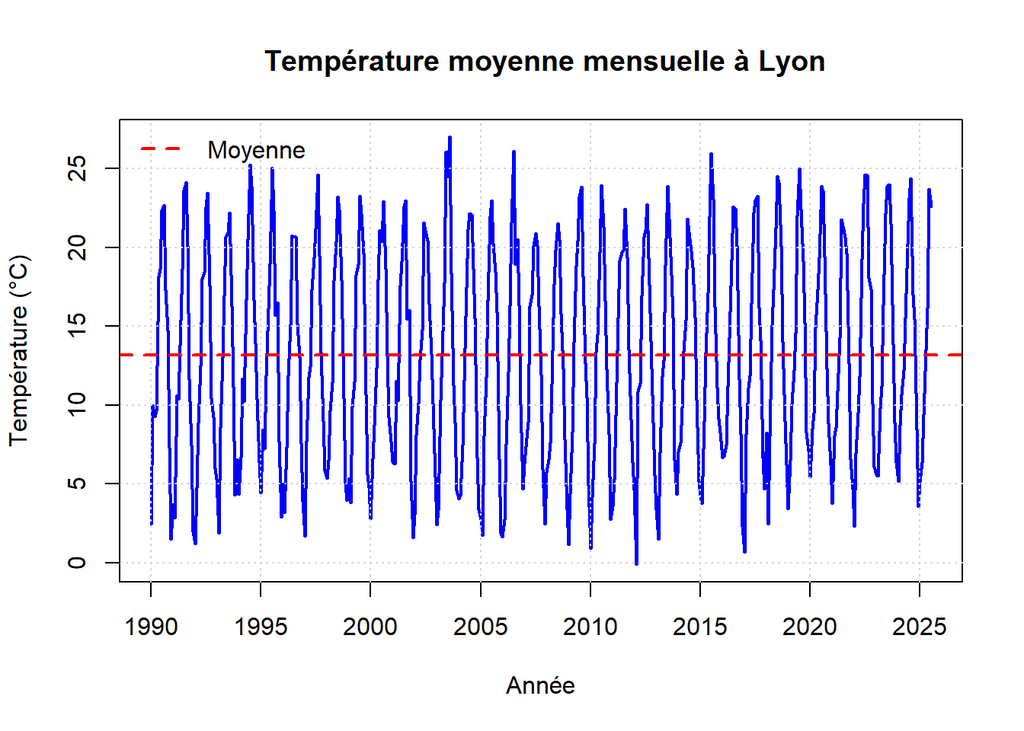

La série temporelle présente une moyenne d’environ 13,2°C et une médiane proche (12,6°C), ce qui suggère une distribution globalement symétrique. La variance (47,2) indique une dispersion modérée des valeurs autour de la moyenne, avec un écart-type d’environ 7°C. Le skewness proche de zéro (0,04) confirme l’absence d’asymétrie marquée, tandis que le kurtosis inférieur à 3 (1,79) traduit une distribution plus aplatie que la normale, avec moins de valeurs extrêmes.

La série présente une forte saisonnalité annuelle (été chaud, hiver froid), avec une amplitude assez stable (~20°C). On peut suspecter une tendance légèrement haussière des températures maximales récentes, mais ce n’est pas flagrant visuellement.

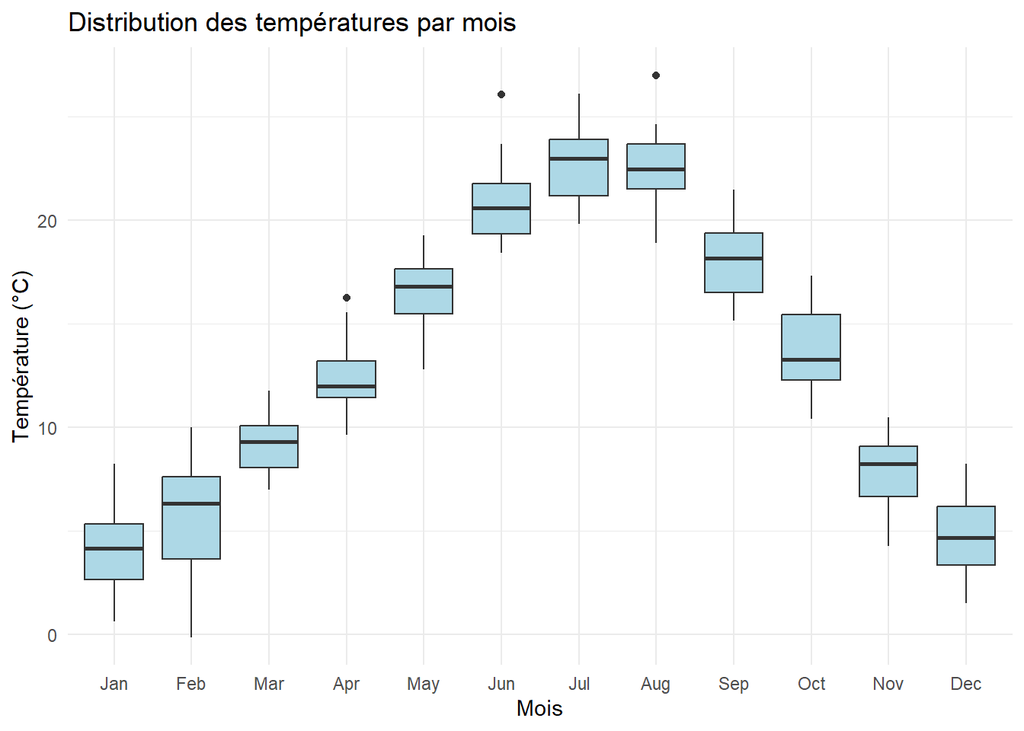

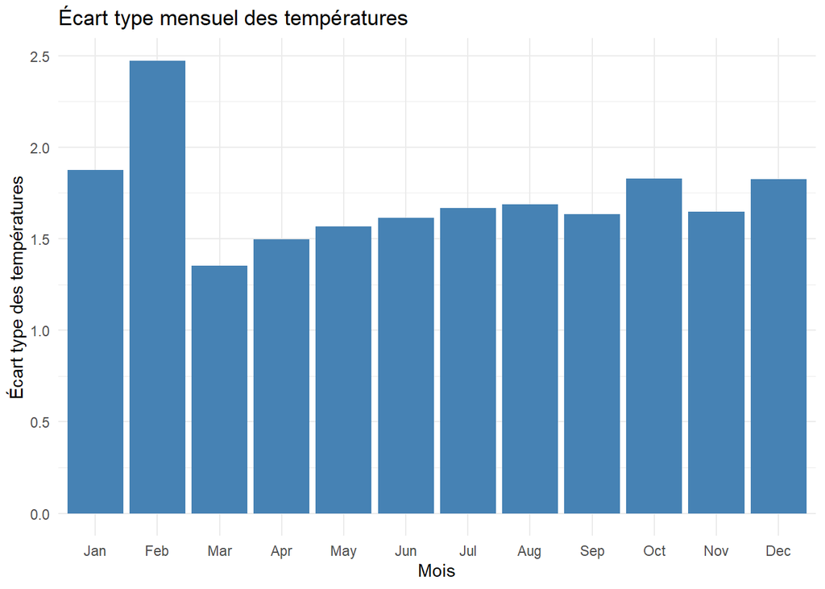

La volatilité dépend du mois étudié. Sur le graphe on voit l’hétéroscélasticité des températures, notament un écart type plus important pour le mois de Janvier avec un écart type de 1.876471°C ou Février avec 2.472963°c contre un écart type de température plus faible pour les mois de Mars ou Avril (1.350898°C resp. 1.497665°C) par exemple.

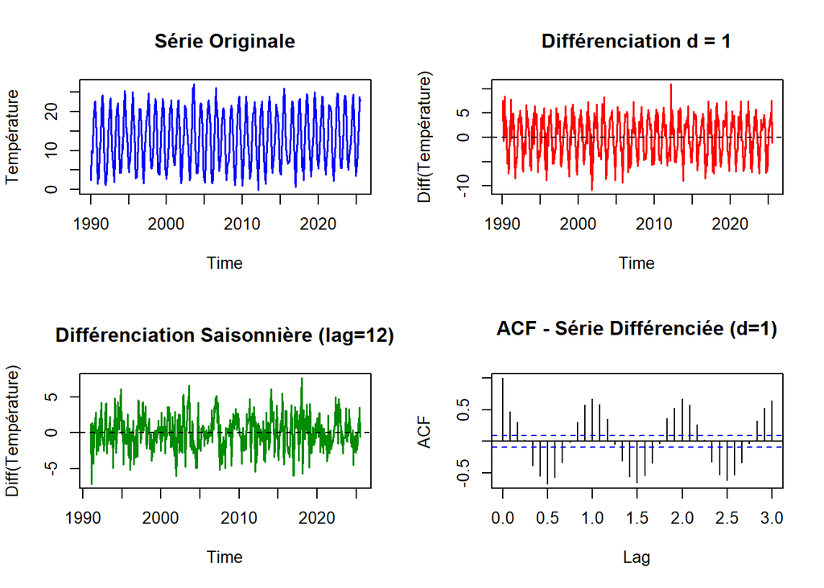

```
##
## Test ADF après différenciation (d=1) :
```

```
## p-value : 0.01
```

La différentiationd’ordre 1 n’est pas satisfaisante. Regardons avec lag 12.

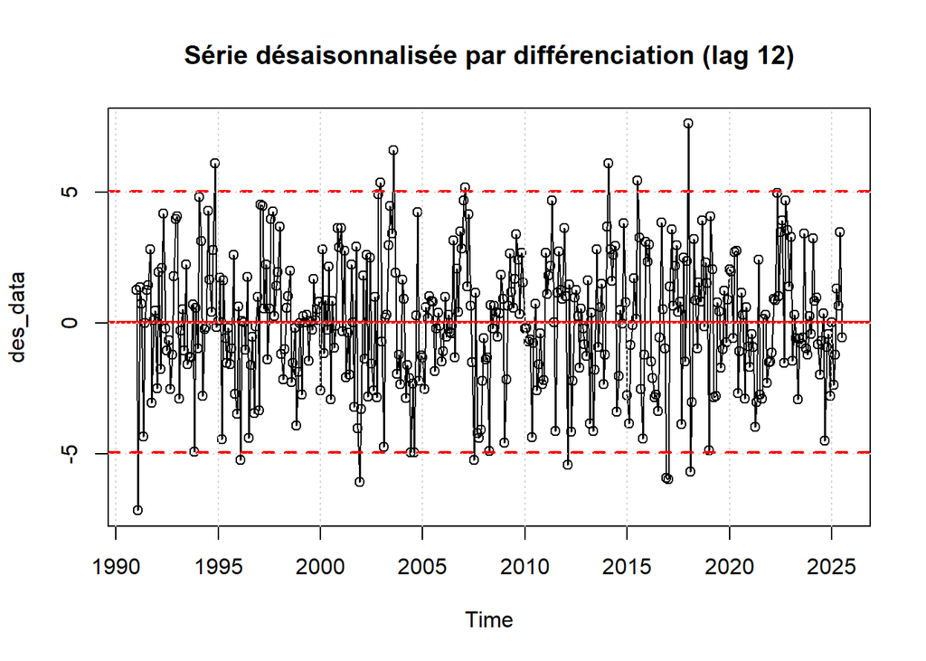

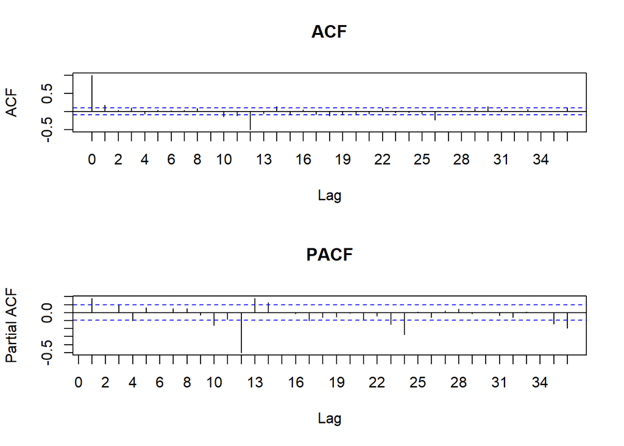

```
##
##  Augmented Dickey-Fuller Test
##
## data:  des_data
## Dickey-Fuller = -6.0214, Lag order = 7, p-value = 0.01
## alternative hypothesis: stationary
```

```
## INTERPRÉTATION DU TEST ADF :
## -----------------------------
## - H0 : la série n'est pas Stationnaire
## - p-value < 0.05 → On REJETTE H0
## - ✓ La série est stationnaire.
```

```
##
## Test KPSS sur la série brute :
```

```
## Statistique KPSS : 0.0148
```

```
## p-value : 0.1
```

```
## ✓ La série est STATIONNAIRE (p ≥ 0.05)
```

Deux tests statistiques ont été appliqués à la série désaisonnalisée : Test ADF (Augmented Dickey-Fuller) :

Statistique = -6.02

p-value = 0.01 → On rejette l’hypothèse de non-stationnarité, la série est donc stationnaire.

Test KPSS (Kwiatkowski-Phillips-Schmidt-Shin) :

Statistique = 0.0148

p-value = 0.1 → On ne rejette pas l’hypothèse de stationnarité. Les deux tests aboutissent à la même conclusion : la série des_data est stationnaire après différenciation annuelle. Cela confirme que la tendance et la saisonnalité ont été correctement supprimées, et que la série est maintenant prête pour la modélisation ARIMA.

```
##    type ordre      AIC      BIC
## 1    AR     1 1927.719 1939.804
## 2    AR     2 1929.719 1945.832
## 3    AR     3 1927.366 1947.507
## 4    AR     4 1924.823 1948.993
## 5    AR     5 1925.133 1953.331
## 6    MA     1 1927.547 1939.632
## 7    MA     2 1929.420 1945.533
## 8    MA     3 1923.309 1943.450
## 9    MA     4 1921.099 1945.268
## 10   MA     5 1920.221 1948.419
```

```
## Meilleur modèle selon AIC: MA ( 5 )
##  Meilleur modèle selon BIC: MA ( 1 )
##  Meilleur modèle AR selon AIC: AR ( 4 )
##  Meilleur modèle AR selon BIC: AR ( 1 )
##  Meilleur modèle MA selon AIC: MA ( 5 )
##  Meilleur modèle MA selon BIC: MA ( 1 )
```

Effectivement, les modèles avec plus de paramètres ont un meilleur AIC mais c’est dû à un “sur-apprentissage” qui est mis en évidence par la mesure du BIC qui met les modèles AR(1) et MA(1) en avant. On comprend bien intuitivement que la température moyenne pour le mois de juin par exemple dépend peu de la température de la même année en Janvier.

```
##
## Meilleur modèle ARMA selon AIC: ARMA( 5 0 5 )
##  Meilleur modèle ARMA selon BIC: ARMA( 5 0 5 )
```

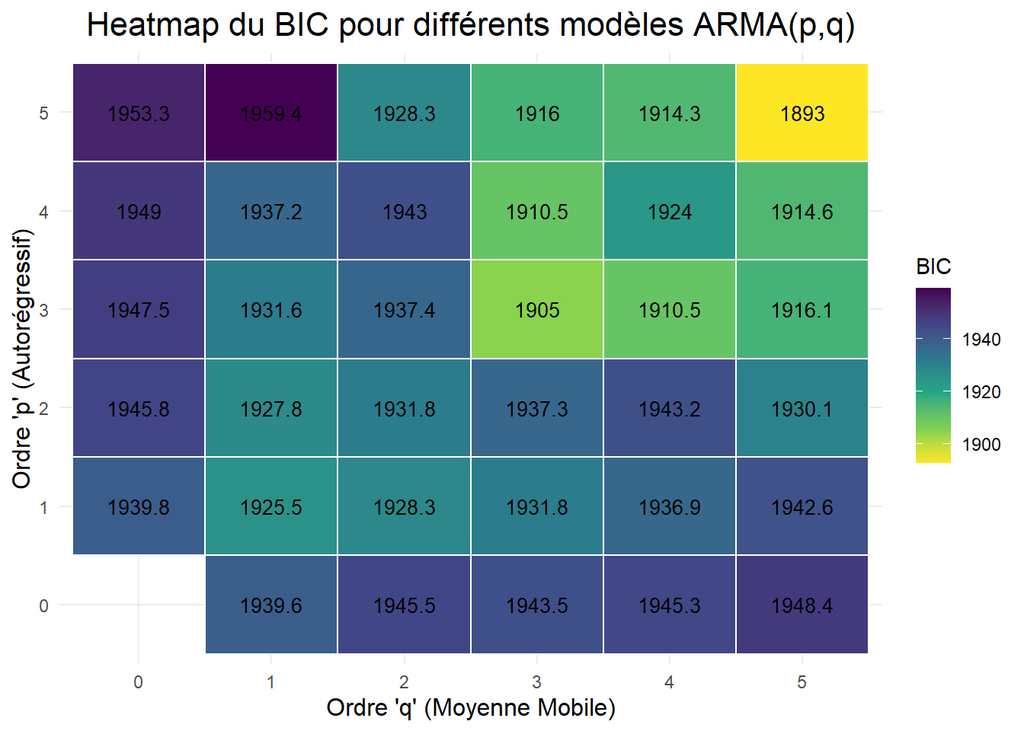

Analyse des résidus : Pour le modèle AR(4) :

L’ACF des résidus montre encore des pics significatifs → autocorrélations résiduelles non négligeables.

Le test de Ljung–Box (p-value < 0.001) confirme la présence d’autocorrélation → modèle insuffisant.

Pour le modèle ARMA(5,5) :

L’histogramme des résidus est centré sur 0, proche d’une distribution normale.

Conclusion : Le modèle ARMA(5,5) améliore nettement l’ajustement par rapport au modèle AR(4), mais c’est le modèle saisonnier ARMA(12,12) restreint qui fournit les résidus les plus satisfaisants (non autocorrélés et à moyenne nulle). Il constitue donc le meilleur modèle pour la série désaisonnalisée.

Partie 2 : Modélisation et analyse

```
## [1] 1924.823
```

```
## [1] 1844.665
```

Les résidus ne peuvent pas être considéré comme des bruits blancs au vu du test de Ljung-Box avec des p_value égal à des 0 machine. On le voit avec le plot des ACF des 2 modèles qui montrent une corrélation au lag 12 (Le mois de l’année précedente).

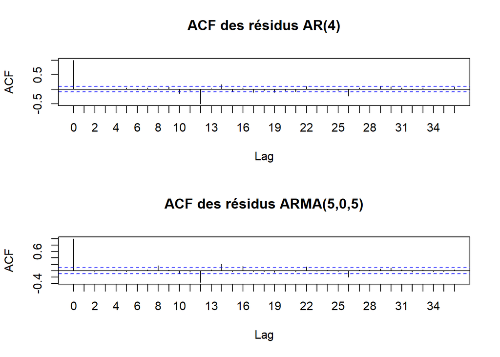

```
##
##  Box-Ljung test
##
## data:  res_AR
## X-squared = 120.67, df = 12, p-value < 2.2e-16
```

```
##
##  Box-Ljung test
##
## data:  res_ARMA
## X-squared = 72.822, df = 12, p-value = 9.463e-11
```

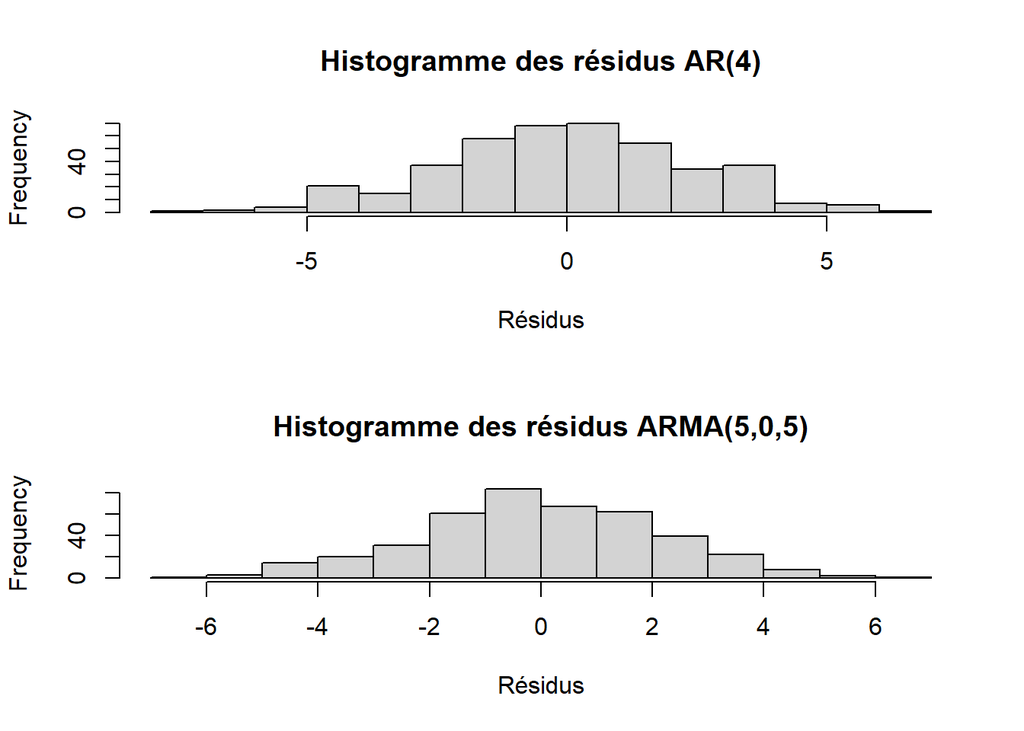

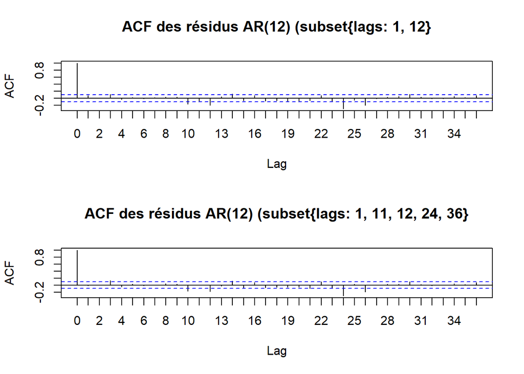

```
##
##  Box-Ljung test
##
## data:  res_subsetAR_12
## X-squared = 41.747, df = 12, p-value = 3.673e-05
```

```
##
##  Box-Ljung test
##
## data:  res_subsetAR_36
## X-squared = 36.894, df = 12, p-value = 0.0002324
```

```
##
##  Box-Ljung test
##
## data:  res_subsetAR_36
## X-squared = 109.36, df = 25, p-value = 1.588e-12
```

```
##
##  Box-Ljung test
##
## data:  res_subsetARMA
## X-squared = 13.728, df = 12, p-value = 0.3184
```

```
## [1] 415
```

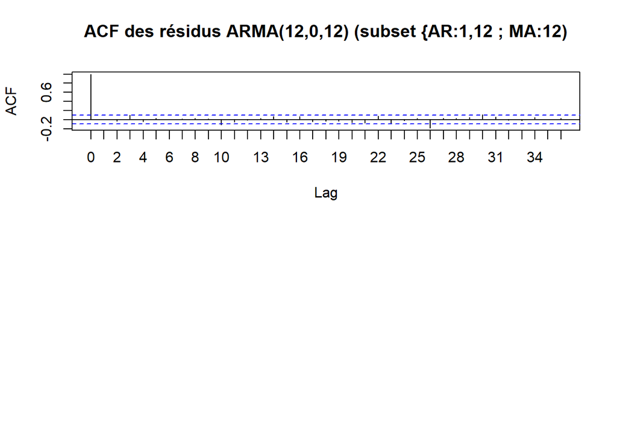

## Test de Ljung–Box

La statistique du test est donnée par :

$$Q = n (n + 2) \sum_{k=1}^{m} \frac{\hat{\rho}(k)^2}{n - k}$$

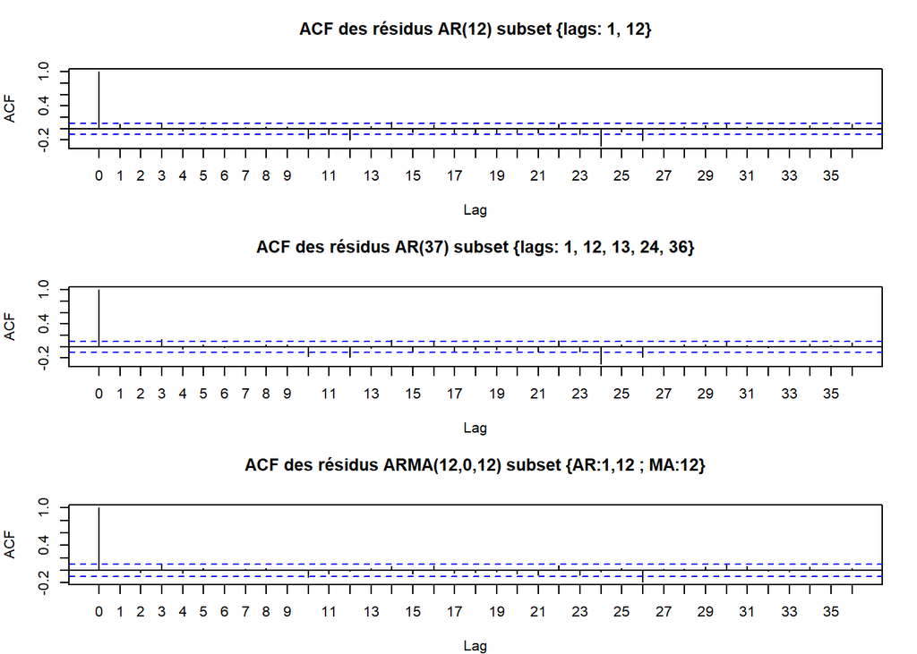

[figure not shown]

[figure not shown]

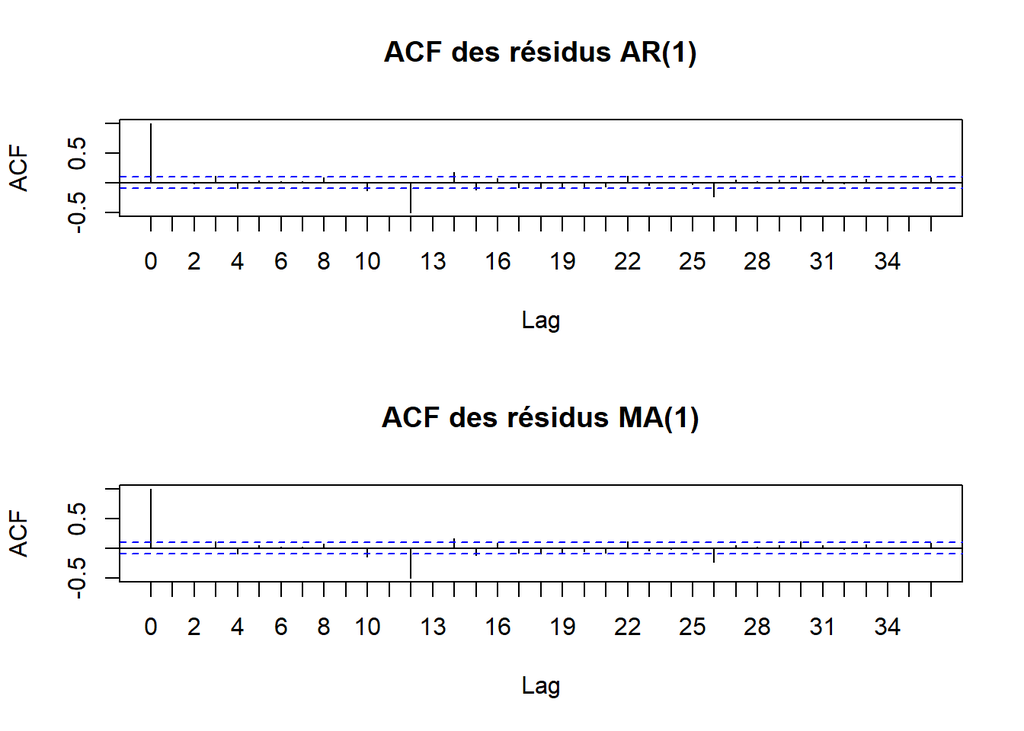

```
##
##  Box-Ljung test
##
## data:  res_AR_1
## X-squared = 129.55, df = 12, p-value < 2.2e-16
```

```
##
##  Box-Ljung test
##
## data:  res_MA_1
## X-squared = 130.88, df = 12, p-value < 2.2e-16
```

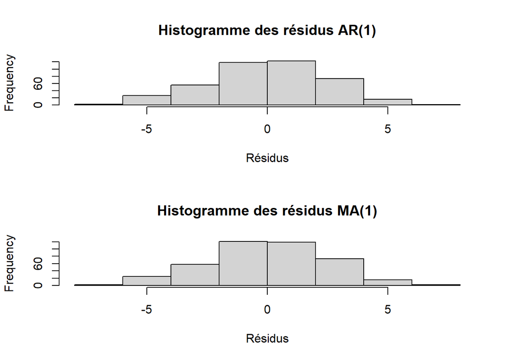

```
## Sélection automatique du meilleur modèle ARIMA...
```

```
##
##  ARIMA(0,0,0)            with zero mean     : 1936.831
##  ARIMA(0,0,0)            with non-zero mean : 1938.797
##  ARIMA(0,0,0)(0,0,1)[12] with zero mean     : Inf
##  ARIMA(0,0,0)(0,0,1)[12] with non-zero mean : Inf
##  ARIMA(0,0,0)(0,0,2)[12] with zero mean     : Inf
##  ARIMA(0,0,0)(0,0,2)[12] with non-zero mean : Inf
##  ARIMA(0,0,0)(1,0,0)[12] with zero mean     : 1813.257
##  ARIMA(0,0,0)(1,0,0)[12] with non-zero mean : 1814.972
##  ARIMA(0,0,0)(1,0,1)[12] with zero mean     : Inf
##  ARIMA(0,0,0)(1,0,1)[12] with non-zero mean : Inf
##  ARIMA(0,0,0)(1,0,2)[12] with zero mean     : 1684.991
##  ARIMA(0,0,0)(1,0,2)[12] with non-zero mean : Inf
##  ARIMA(0,0,0)(2,0,0)[12] with zero mean     : 1748.268
##  ARIMA(0,0,0)(2,0,0)[12] with non-zero mean : 1749.461
##  ARIMA(0,0,0)(2,0,1)[12] with zero mean     : 1684.581
##  ARIMA(0,0,0)(2,0,1)[12] with non-zero mean : Inf
##  ARIMA(0,0,0)(2,0,2)[12] with zero mean     : Inf
##  ARIMA(0,0,0)(2,0,2)[12] with non-zero mean : Inf
##  ARIMA(0,0,1)            with zero mean     : 1925.618
##  ARIMA(0,0,1)            with non-zero mean : 1927.606
##  ARIMA(0,0,1)(0,0,1)[12] with zero mean     : Inf
##  ARIMA(0,0,1)(0,0,1)[12] with non-zero mean : Inf
##  ARIMA(0,0,1)(0,0,2)[12] with zero mean     : Inf
##  ARIMA(0,0,1)(0,0,2)[12] with non-zero mean : Inf
##  ARIMA(0,0,1)(1,0,0)[12] with zero mean     : 1800.929
##  ARIMA(0,0,1)(1,0,0)[12] with non-zero mean : 1802.737
##  ARIMA(0,0,1)(1,0,1)[12] with zero mean     : Inf
##  ARIMA(0,0,1)(1,0,1)[12] with non-zero mean : Inf
##  ARIMA(0,0,1)(1,0,2)[12] with zero mean     : Inf
##  ARIMA(0,0,1)(1,0,2)[12] with non-zero mean : Inf
##  ARIMA(0,0,1)(2,0,0)[12] with zero mean     : 1741.586
##  ARIMA(0,0,1)(2,0,0)[12] with non-zero mean : 1742.995
##  ARIMA(0,0,1)(2,0,1)[12] with zero mean     : Inf
##  ARIMA(0,0,1)(2,0,1)[12] with non-zero mean : Inf
##  ARIMA(0,0,1)(2,0,2)[12] with zero mean     : Inf
##  ARIMA(0,0,1)(2,0,2)[12] with non-zero mean : Inf
##  ARIMA(0,0,2)            with zero mean     : 1927.522
##  ARIMA(0,0,2)            with non-zero mean : 1929.518
##  ARIMA(0,0,2)(0,0,1)[12] with zero mean     : Inf
```

[output cut: 142 more lines]

```
##  ARIMA(3,0,2)            with non-zero mean : 1909.52
##  ARIMA(4,0,0)            with zero mean     : 1923.008
##  ARIMA(4,0,0)            with non-zero mean : 1925.029
##  ARIMA(4,0,0)(0,0,1)[12] with zero mean     : Inf
##  ARIMA(4,0,0)(0,0,1)[12] with non-zero mean : Inf
##  ARIMA(4,0,0)(1,0,0)[12] with zero mean     : 1799.596
##  ARIMA(4,0,0)(1,0,0)[12] with non-zero mean : 1801.487
##  ARIMA(4,0,1)            with zero mean     : 1907.284
##  ARIMA(4,0,1)            with non-zero mean : 1909.325
##  ARIMA(5,0,0)            with zero mean     : 1923.37
##  ARIMA(5,0,0)            with non-zero mean : 1925.408
##
##
##
##  Best model: ARIMA(1,0,1)(2,0,1)[12] with zero mean
```

```
## MEILLEUR MODÈLE SÉLECTIONNÉ
```

```
## Series: des_data
## ARIMA(1,0,1)(2,0,1)[12] with zero mean
##
## Coefficients:
##           ar1     ma1     sar1     sar2     sma1
##       -0.5596  0.7149  -0.0828  -0.0461  -0.8856
## s.e.   0.1554  0.1313   0.0615   0.0585   0.0441
##
## sigma^2 = 3.093:  log likelihood = -831.23
## AIC=1674.46   AICc=1674.67   BIC=1698.63
##
## Training set error measures:
##                     ME     RMSE      MAE MPE MAPE      MASE       ACF1
## Training set 0.1965763 1.748182 1.428169 Inf  Inf 0.4074517 0.01816156
```

Comparaison des Modèles ARIMA

|  | Modèle | AIC | BIC | AICc | LogLik |
| --- | --- | --- | --- | --- | --- |
| 1 | Auto ARIMA | 1674.46 | 1698.63 | 1674.67 | -831.23 |
| ARIMA(2,0,2)(2,0,0)[12] | ARIMA(2,0,2)(2,0,0)[12] | 1742.40 | 1774.62 | 1742.75 | -863.20 |
| ARIMA(1,1,2)(2,1,1)[12] | ARIMA(1,1,2)(2,1,1)[12] | 1762.22 | 1790.22 | 1762.51 | -874.11 |
| ARIMA(2,1,2)(1,1,1)[12] | ARIMA(2,1,2)(1,1,1)[12] | 1808.50 | 1836.49 | 1808.79 | -897.25 |
| ARIMA(1,1,1)(1,1,1)[12] | ARIMA(1,1,1)(1,1,1)[12] | 1815.60 | 1835.59 | 1815.75 | -902.80 |

```
##
## ✓ Le meilleur modèle selon AICc est : Auto ARIMA
```

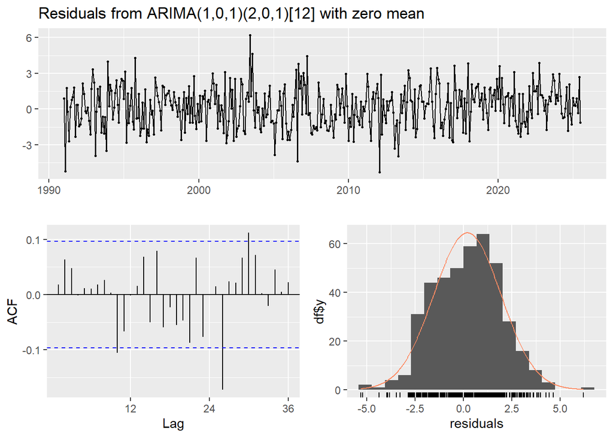

```
##
##  Ljung-Box test
##
## data:  Residuals from ARIMA(1,0,1)(2,0,1)[12] with zero mean
## Q* = 27.791, df = 19, p-value = 0.08753
##
## Model df: 5.   Total lags used: 24
```

```
## Test de Ljung-Box (H0 : pas d'autocorrélation) :
```

```
##   p-value = 0.1907
```

```
##   ✓ Les résidus sont un bruit blanc (p > 0.05)
```

```
## Test de Shapiro-Wilk (H0 : normalité) :
```

```
##   p-value = 0.3045
```

```
##   ✓ Les résidus suivent une loi normale (p > 0.05)
```

Les modèles qui ont passé la test de Box-Ljung sont les modèles ARIMA(1,0,1)(2,0,1)[12], ARMA(12,0,12) subset {AR:1,12 ; MA:12} équivalent à ARIMA(1,0,0)(1,0,1)[12]

3. Analyse des résidus

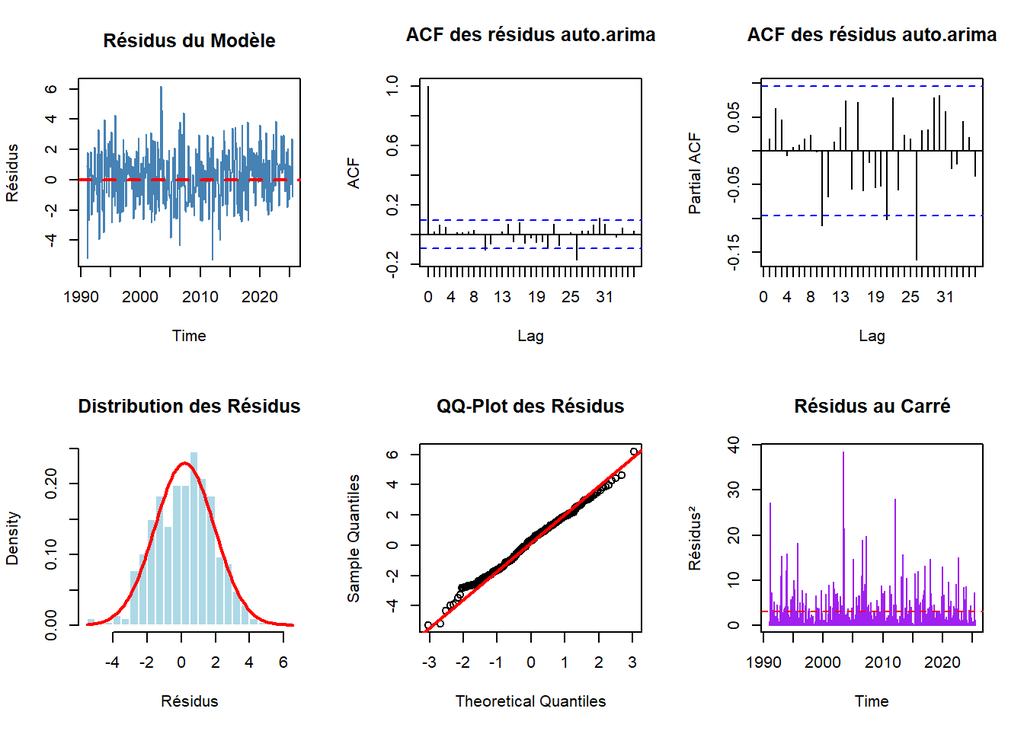

## Modèles ARCH et GARCH

1. Test Arche Engle

```
##
##  ARCH LM-test; Null hypothesis: no ARCH effects
##
## data:  residus
## Chi-squared = 15.49, df = 12, p-value = 0.2157
```

```
##
##  ARCH LM-test; Null hypothesis: no ARCH effects
##
## data:  res_subsetARMA
## Chi-squared = 10.596, df = 12, p-value = 0.5638
```

2. Modèle ARCH(1) & GARCH(1,1)
3. Critères AIC & BIC

```
##
## *---------------------------------*
## *          GARCH Model Fit        *
## *---------------------------------*
##
## Conditional Variance Dynamics
## -----------------------------------
## GARCH Model  : sGARCH(1,0)
## Mean Model   : ARFIMA(12,0,12)
## Distribution : norm
##
## Optimal Parameters
## ------------------------------------
##         Estimate  Std. Error   t value Pr(>|t|)
## mu      0.029913    0.021986   1.36054 0.173660
## ar1     0.170133    0.050663   3.35816 0.000785
## ar2     0.000000          NA        NA       NA
## ar3     0.000000          NA        NA       NA
## ar4     0.000000          NA        NA       NA
## ar5     0.000000          NA        NA       NA
## ar6     0.000000          NA        NA       NA
## ar7     0.000000          NA        NA       NA
## ar8     0.000000          NA        NA       NA
## ar9     0.000000          NA        NA       NA
## ar10    0.000000          NA        NA       NA
## ar11    0.000000          NA        NA       NA
## ar12   -0.051428    0.057577  -0.89320 0.371748
## ma1     0.000000          NA        NA       NA
## ma2     0.000000          NA        NA       NA
## ma3     0.000000          NA        NA       NA
## ma4     0.000000          NA        NA       NA
## ma5     0.000000          NA        NA       NA
## ma6     0.000000          NA        NA       NA
## ma7     0.000000          NA        NA       NA
## ma8     0.000000          NA        NA       NA
## ma9     0.000000          NA        NA       NA
## ma10    0.000000          NA        NA       NA
## ma11    0.000000          NA        NA       NA
## ma12   -0.807436    0.033101 -24.39322 0.000000
## omega   3.201441    0.290469  11.02164 0.000000
```

[output cut: 85 more lines]

```
## Negative Sign Bias  0.2865 0.7746
## Positive Sign Bias  0.1358 0.8920
## Joint Effect        0.5920 0.8983
##
##
## Adjusted Pearson Goodness-of-Fit Test:
## ------------------------------------
##   group statistic p-value(g-1)
## 1    20     21.10       0.3315
## 2    30     37.46       0.1349
## 3    40     46.98       0.1782
## 4    50     50.66       0.4078
##
##
## Elapsed time : 0.2764552
```

```
##
## *---------------------------------*
## *          GARCH Model Fit        *
## *---------------------------------*
##
## Conditional Variance Dynamics
## -----------------------------------
## GARCH Model  : sGARCH(1,1)
## Mean Model   : ARFIMA(12,0,12)
## Distribution : norm
##
## Optimal Parameters
## ------------------------------------
##         Estimate  Std. Error     t value Pr(>|t|)
## mu      0.031747    0.021064  1.5072e+00  0.13177
## ar1     0.170268    0.049486  3.4407e+00  0.00058
## ar2     0.000000          NA          NA       NA
## ar3     0.000000          NA          NA       NA
## ar4     0.000000          NA          NA       NA
## ar5     0.000000          NA          NA       NA
## ar6     0.000000          NA          NA       NA
## ar7     0.000000          NA          NA       NA
## ar8     0.000000          NA          NA       NA
## ar9     0.000000          NA          NA       NA
## ar10    0.000000          NA          NA       NA
## ar11    0.000000          NA          NA       NA
## ar12   -0.059221    0.057487 -1.0302e+00  0.30293
## ma1     0.000000          NA          NA       NA
## ma2     0.000000          NA          NA       NA
## ma3     0.000000          NA          NA       NA
## ma4     0.000000          NA          NA       NA
## ma5     0.000000          NA          NA       NA
## ma6     0.000000          NA          NA       NA
## ma7     0.000000          NA          NA       NA
## ma8     0.000000          NA          NA       NA
## ma9     0.000000          NA          NA       NA
## ma10    0.000000          NA          NA       NA
## ma11    0.000000          NA          NA       NA
## ma12   -0.812430    0.032282 -2.5167e+01  0.00000
## omega   0.001429    0.007471  1.9134e-01  0.84826
```

[output cut: 88 more lines]

```
## Negative Sign Bias 0.01613 0.9871
## Positive Sign Bias 0.27026 0.7871
## Joint Effect       0.48587 0.9220
##
##
## Adjusted Pearson Goodness-of-Fit Test:
## ------------------------------------
##   group statistic p-value(g-1)
## 1    20     15.99       0.6581
## 2    30     30.08       0.4098
## 3    40     29.63       0.8607
## 4    50     48.98       0.4741
##
##
## Elapsed time : 0.157248
```

```
##
## Akaike       4.097812
## Bayes        4.156052
## Shibata      4.097402
## Hannan-Quinn 4.120842
```

```
##
## Akaike       4.097181
## Bayes        4.165128
## Shibata      4.096624
## Hannan-Quinn 4.124049
```

La comparaison des critères montre des écarts très faibles entre les deux modèles. L’AIC est légèrement plus bas pour le GARCH(1,1), suggérant un gain assez minime. En revanche le BIC est légèrement plus bas pour le ARCH(1), ce qui suggère que le modèle ARCH(1) est moins complexe. Ces deux critères ne reflètent pas un avantage d’un modèle par rapport à l’autre.

On remarque que a dispersion des températures s’avérant systématiquement plus élevée en hiver qu’en été. Nous pouvons donc retenir un modèle à variance saisonnière attribuant un écart-type par mois, ce qui évite d’alourdir le modèle avec un GARCH.

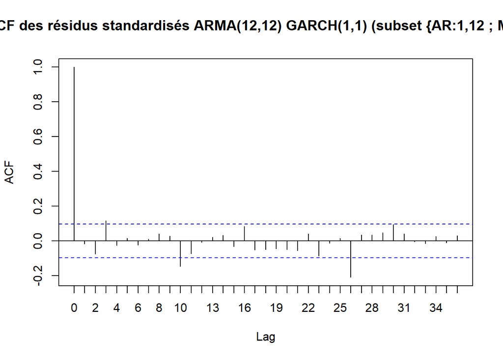

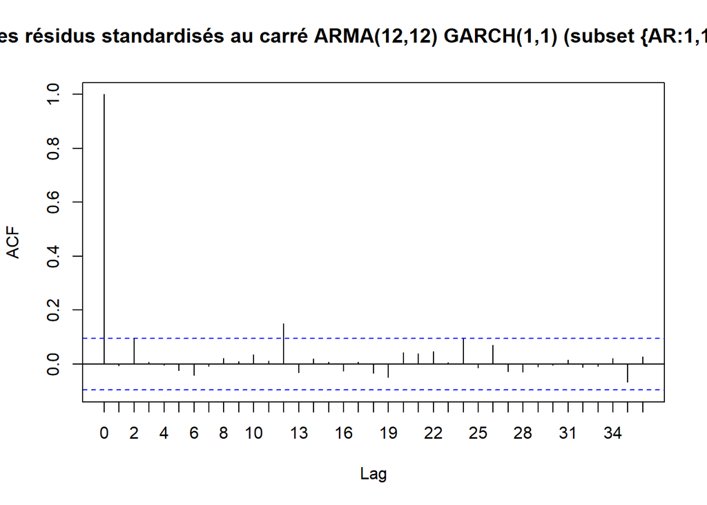

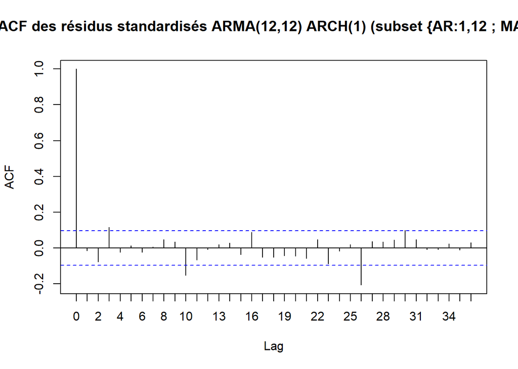

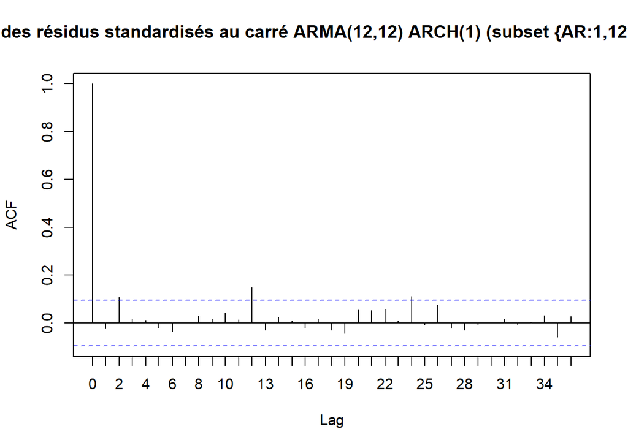

```
##
##  Box-Ljung test
##
## data:  z_subsetARMA_GARCH
## X-squared = 29.557, df = 20, p-value = 0.07735
```

```
##
##  Box-Ljung test
##
## data:  z_subsetARMA_GARCH^2
## X-squared = 18.482, df = 20, p-value = 0.5557
```

```
##
##  Box-Ljung test
##
## data:  z_subsetARMA_ARCH
## X-squared = 30.776, df = 20, p-value = 0.05822
```

```
##
##  Box-Ljung test
##
## data:  z_subsetARMA_ARCH^2
## X-squared = 19.84, df = 20, p-value = 0.468
```

4. Résidus finaux

Pour les deux modèles les test des résidus ne sont pas signifiactifs , ce qui suggère une autocorrélation résiduelle légère. En revanche, pour les deux modèles, Box-Ljung indique l’abscence d’hétéroscédasticité résiduelle sur les résidus au carré. De plus, les ACF restent globalement dans les bandes de confiance avec quelques pics isolés vers les lag 12 et 24, ce qui est cohérent avec la saisonnalité. Cependant, il n’y a aucun motif systématique. Ce qui confirme que la moyenne est bien spécifiée et que la variance résiduelle ne présente plus de structure marquée.

Ainsi, nous priviligions au vu de ces résultats le modèle le moins complexe : ARMA(12,0,12) subset {AR:1,12 ; MA:12} - ARCH(1)

## Prévision

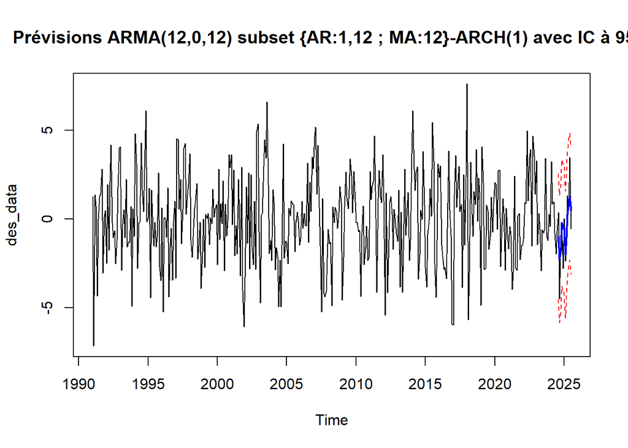

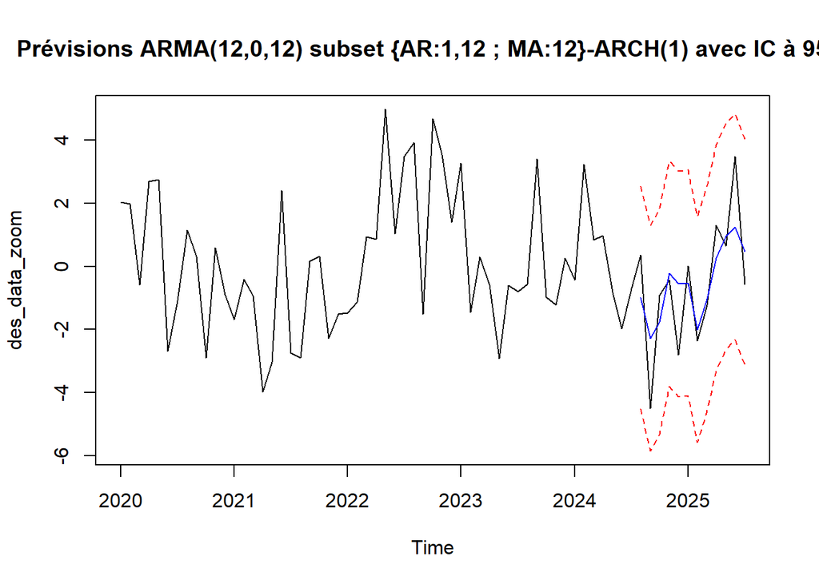

```
## MSE :  1.685225
##  MAPE :  3.36833
```

1/2/3. Prévisions & performances

Nous avons produit une prévision à 12 mois avec le modèle retenu (ARMA(12,12) subset {AR:1,12 ; MA:12} – ARCH(1)) et tracé les prévisions ponctuelles avec leurs IC à 95 %. Les bandes couvrent l’ensemble des observations. On obtient un critère MSE à 1,685 °C², et un critère MAPE à 3,37 %. 3,37 %. Ces niveaux indiquent des erreurs de prévision modérées pour des températures mensuelles : en moyenne, l’écart-type de l’erreur est de l’ordre de 1,3 °C et l’erreur relative tourne autour de 3–4 %.

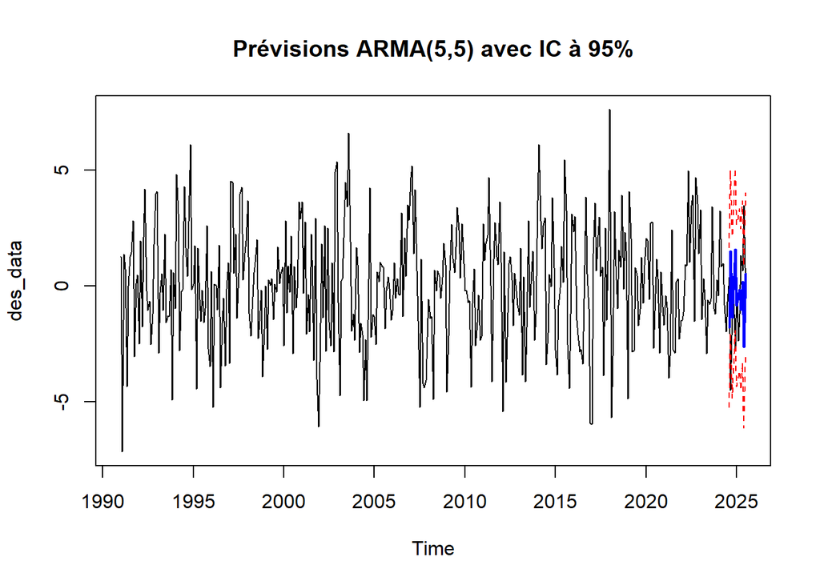

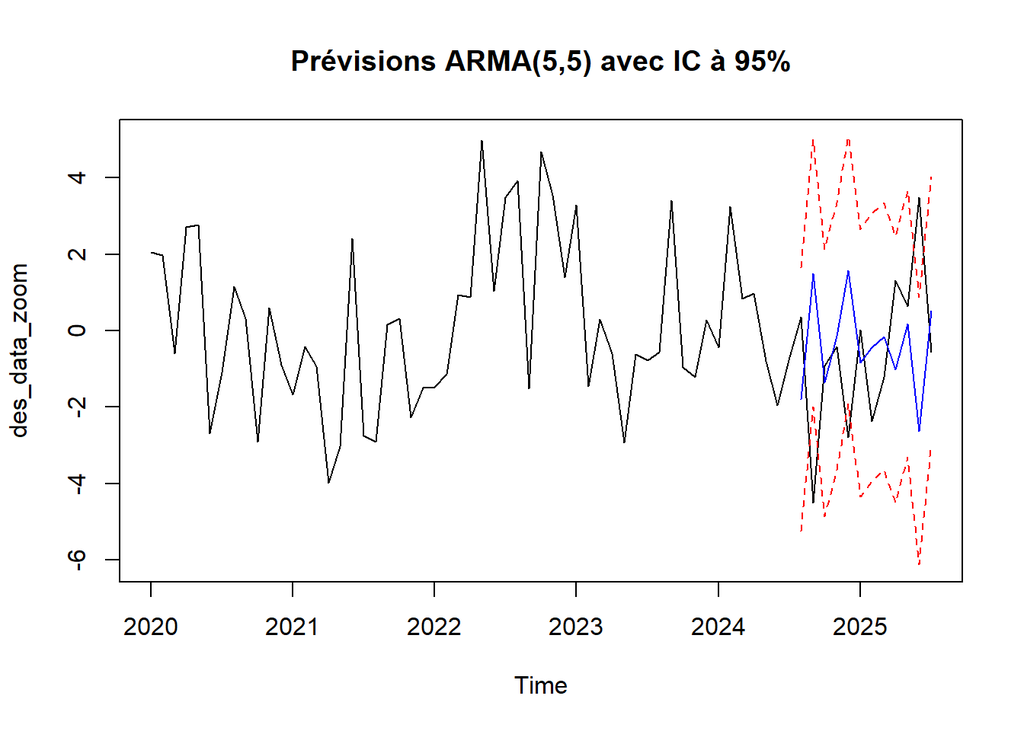

```
## MSE :  9.151211
##  MAPE :  5.514266
```

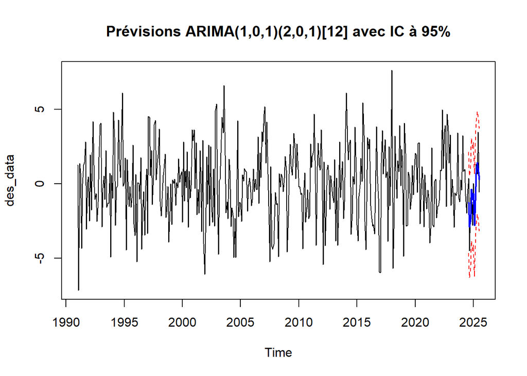

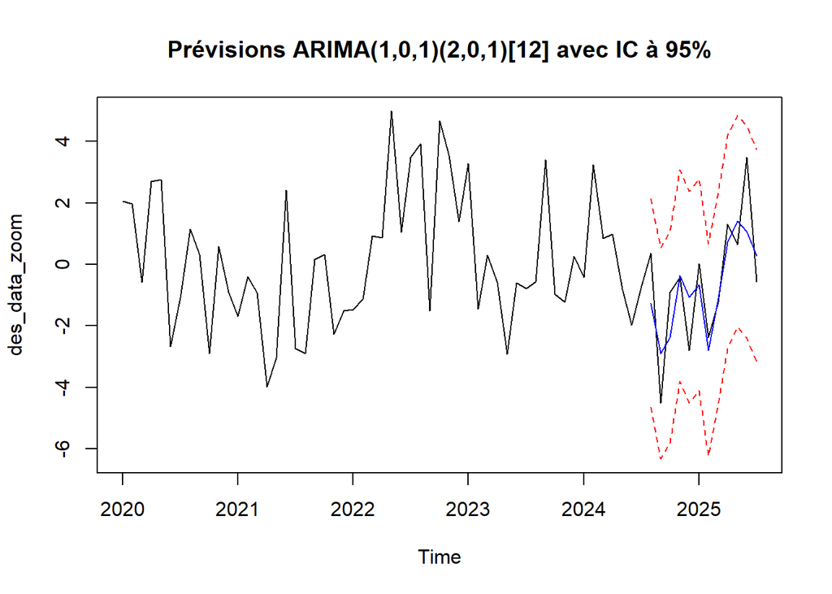

```
## MSE :  1.54128
##  MAPE :  4.109643
```

[output not shown]

4/5. Comparer, analyser et commenter les résultats